# MSRR CH09, Sections 1-3 HW

SOLUTIONS / Jill E. Thomley

Updated: Saturday, March 09, 2019 @ 01:58:46 PM

**Instructions**

Complete the following problems from *Mathematical Statistics with Resampling and R*. You can access the textbook datasets on our [Class Data Files](https://stat-jet-asu.github.io/Datasets/DatasetList.html) page or from the `R` package `resampledata`. The textbook examples use base `R`code for plotting, but you `ggplot2` for visualizations. You may use `table()` to make tables, but you should use `dplyr` for other summaries. Refer to the case studies in Chapter 1 to add informative titles and axis labels to your plots and to provide context for your answers.

Load the packages and datasets you need here.

```r
library(dplyr)
library(ggplot2)
library(moderndive)
library(resampledata)
```

#### Problem 9.6

Part (a)

```r
corr1 <- Olympics2012 %>%
  summarize(correlation = cor(Height, Weight))
corr1
```

```
  correlation
1   0.5083801
```

Part (b)

Note: For “What do you observe?”, comment on linearity, direction of trend, and outliers.

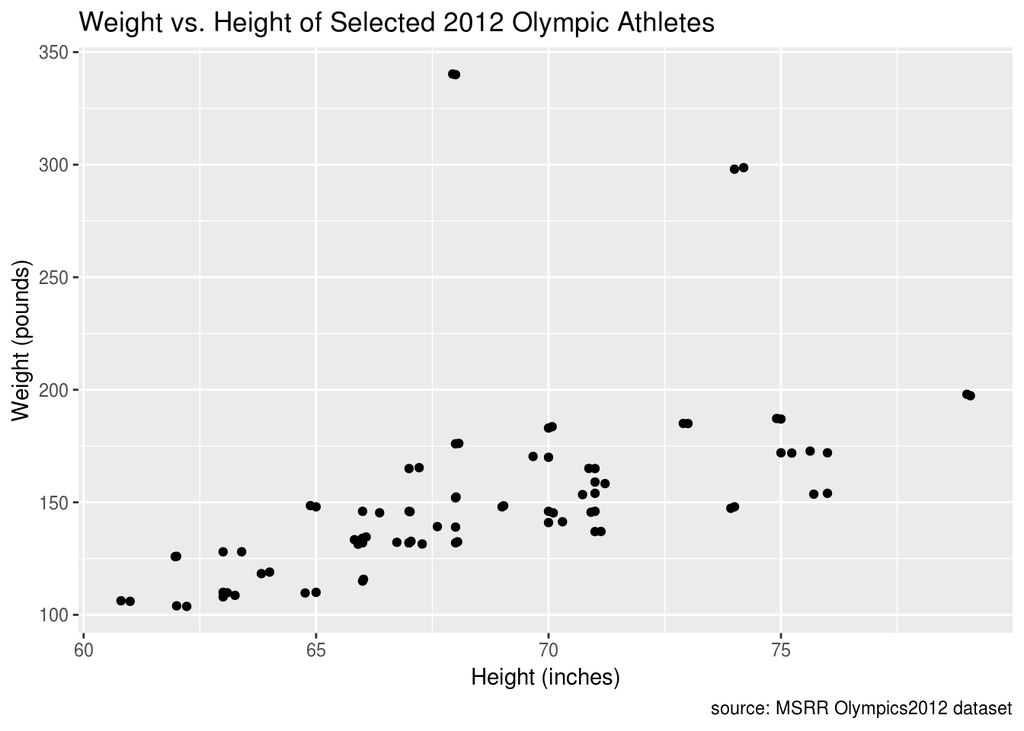

```r
ggplot(Olympics2012, aes(x = Height, y = Weight)) +
  geom_point() +
  geom_jitter() +
  labs(title = "Weight vs. Height of Selected 2012 Olympic Athletes",
       x = "Height (inches)",
       y = "Weight (pounds)",
       caption = "source: MSRR Olympics2012 dataset")
```

ANSWER: There seems to be a positive linear trend where weight increases with height. There are some outliers, people who are unusually heavy compared to others of the same height.

Part (c)

Hint: Use `filter()` with `Weight` to remove the outliers.

```r
corr2 <- Olympics2012 %>%
  filter(Weight < 250) %>%
  summarize(correlation = cor(Height, Weight))
corr_diff <- corr2 - corr1
corr_diff
```

```
  correlation
1   0.2983159
```

ANSWER: The correlation increased by about 0.298 when the outliers were removed, so they appear to haver been influential. The relationship is more strongly linear without those points.

Reminder: You can embed the value of a calculated object like `corr_diff` in the text of your answer rather than typing it by hand. This enhances reprodicibility. See the **Basic R Markdown Cheat Sheet > 5. Embed Code > inline code**.

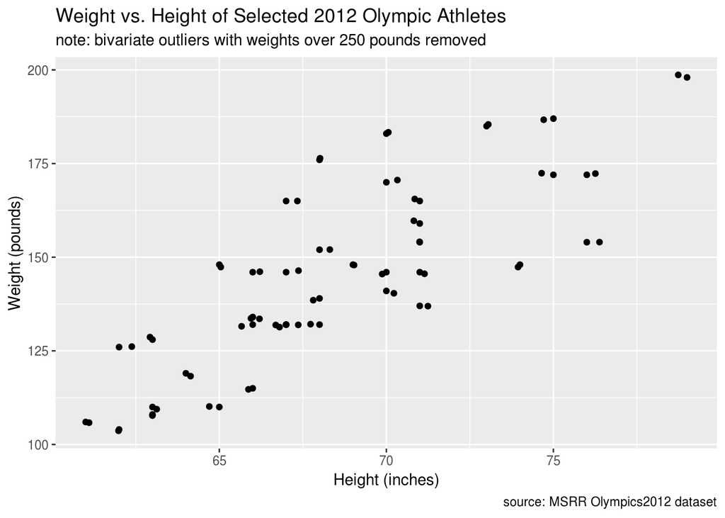

```r
# extra--note you can filter a dataset inside ggplot2
# the trend looks a little less straight in this plot
ggplot(filter(Olympics2012, Weight < 250), aes(x = Height, y = Weight)) +
  geom_point() +
  geom_jitter() +
  labs(title = "Weight vs. Height of Selected 2012 Olympic Athletes",
       subtitle = "note: bivariate outliers with weights over 250 pounds removed",
       x = "Height (inches)",
       y = "Weight (pounds)",
       caption = "source: MSRR Olympics2012 dataset")
```

#### Problem 9.8

Part (a)

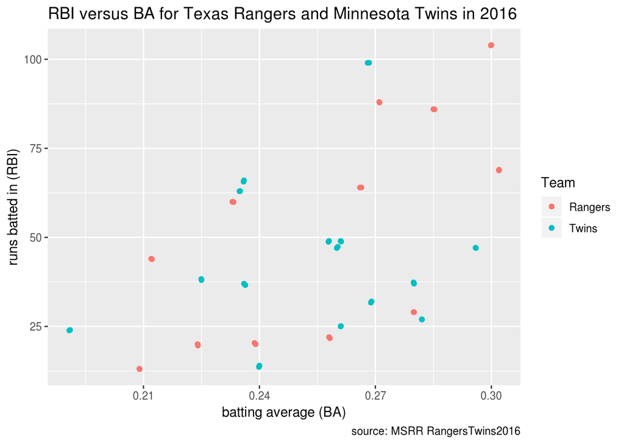

```r
# coloring by team is extra, to help visualize correlation difference
ggplot(RangersTwins2016, aes(x = BA, y = RBI, color = Team)) +
  geom_point() +
  geom_jitter() +
  labs(title = "RBI versus BA for Texas Rangers and Minnesota Twins in 2016",
       x = "batting average (BA)",
       y = "runs batted in (RBI)",
       caption = "source: MSRR RangersTwins2016")
```

```r
RangersTwins2016 %>%
  summarize(correlation = cor(BA, RBI))
```

```
  correlation
1   0.4686685
```

Part (b)

```r
RangersTwins2016 %>%
  group_by(Team) %>%
  summarize(correlation = cor(BA, RBI))
```

```
# A tibble: 2 x 2
  Team    correlation
  <fct>         <dbl>
1 Rangers       0.683
2 Twins         0.156
```

ANSWER: The Rangers alone had a stronger correlation than the combined teams, while the Twins had a weaker correlation. (But, when looking at the plot, neither relationship seems strictly linear.)

#### Problem 9.9

Part (a)

Note: Also make a scatterplot of field goal percentage versus offensive rebounds.

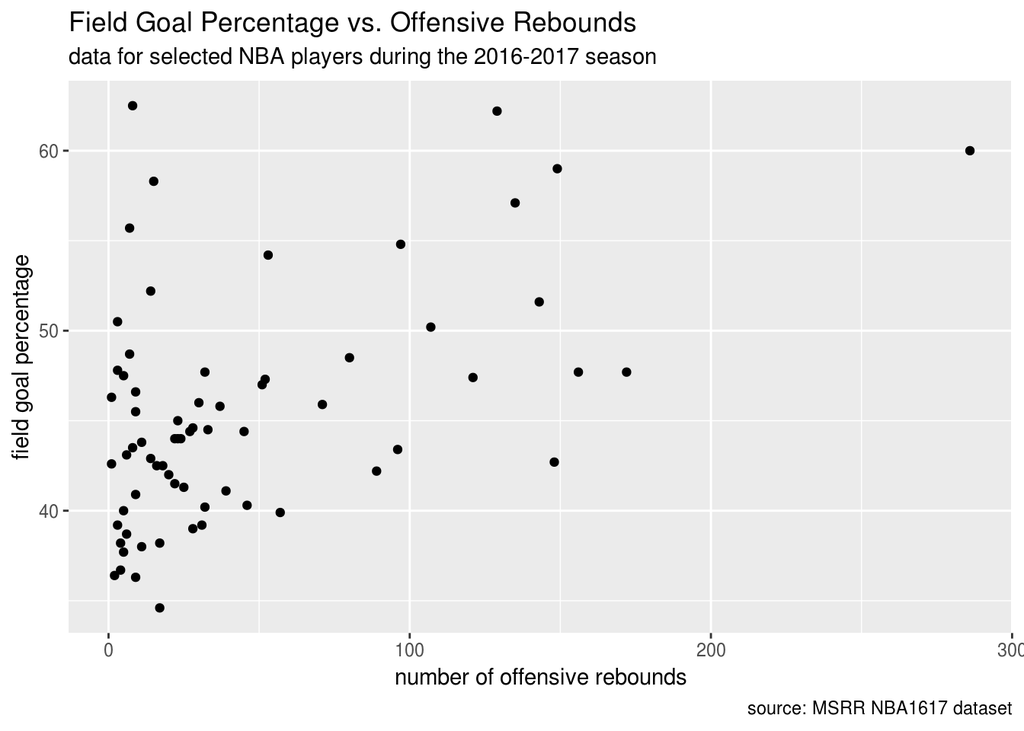

```r
ggplot(NBA1617, aes(x = OffReb, y = PercFG)) +
  geom_point() +
  labs(title = "Field Goal Percentage vs. Offensive Rebounds",
       subtitle = "data for selected NBA players during the 2016-2017 season",
       x = "number of offensive rebounds",
       y = "field goal percentage",
       caption = "source: MSRR NBA1617 dataset")
```

```r
NBA1617 %>%
  summarize(correlation = cor(PercFG, OffReb))
```

```
  correlation
1   0.4898055
```

Part (b)

```r
team_means <- NBA1617 %>%
  group_by(Team) %>%
  summarize(xbar_PercFG = mean(PercFG),
            xbar_OffReb = mean(OffReb))
team_means
```

```
# A tibble: 4 x 3
  Team        xbar_PercFG xbar_OffReb
  <fct>             <dbl>       <dbl>
1 Brooklyn           43.8        37.5
2 Charlotte          46.2        44.7
3 Cleveland          44.8        44.6
4 San Antonio        47.0        51.3
```

Part (c)

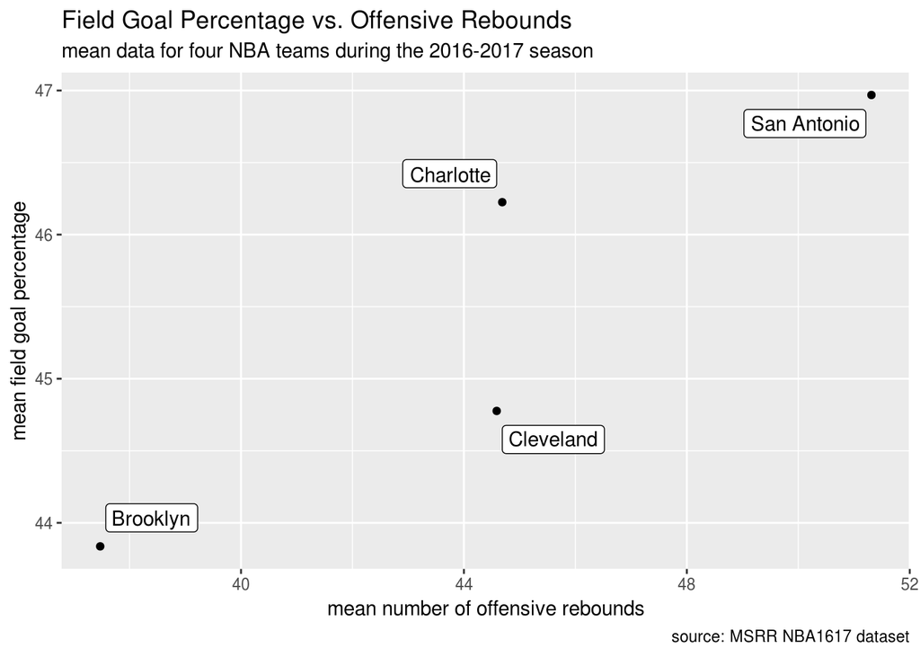

```r
ggplot(team_means, aes(x = xbar_OffReb, y = xbar_PercFG)) +
  geom_point() +
  geom_label(aes(label = Team),
             hjust = c(0, 1, 0, 1),
             nudge_x = c(.1, -.1, .1, -.1),
             vjust = c(0, 0, 1, 1),
             nudge_y = c(.1, .1, -.1, -.1)) +
  labs(title = "Field Goal Percentage vs. Offensive Rebounds",
       subtitle = "mean data for four NBA teams during the 2016-2017 season",
       x = "mean number of offensive rebounds",
       y = "mean field goal percentage",
       caption = "source: MSRR NBA1617 dataset")
```

```r
team_means %>%
  summarize(correlation = cor(xbar_PercFG, xbar_OffReb))
```

```
# A tibble: 1 x 1
  correlation
        <dbl>
1       0.911
```

ANSWER: The correlation is stronger for the averaged team data than the individual players.

#### Problem 9.16

Part (a)

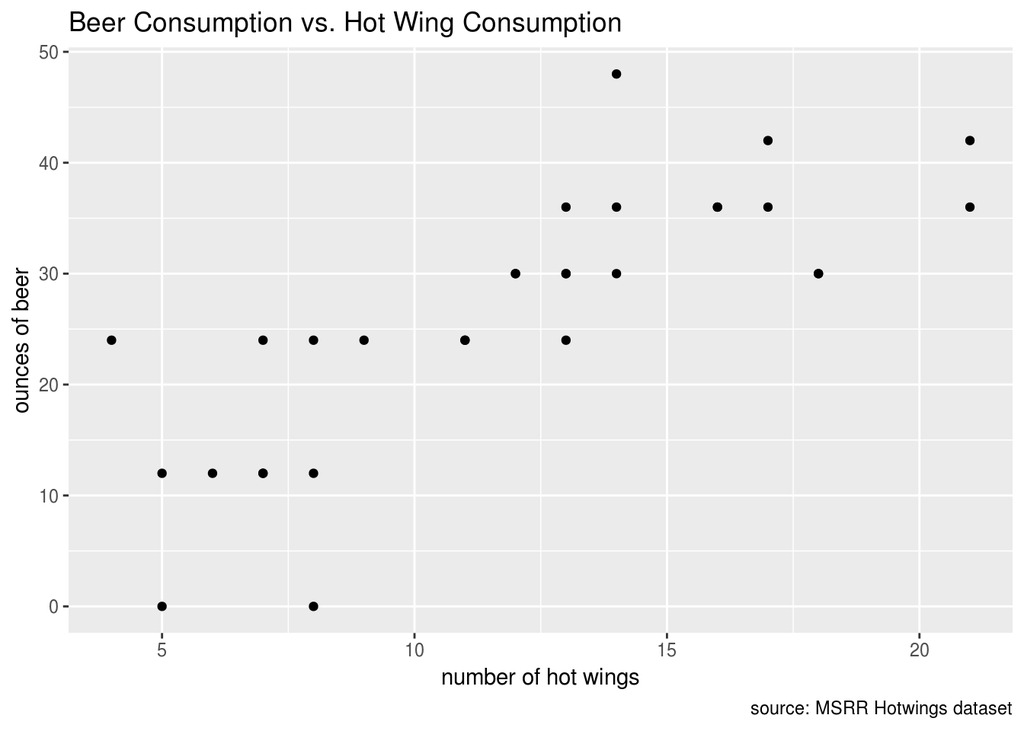

```r
ggplot(Beerwings, aes(x = Hotwings, y = Beer)) +
  geom_point() +
  labs(title = "Beer Consumption vs. Hot Wing Consumption",
       x = "number of hot wings",
       y = "ounces of beer",
       caption = "source: MSRR Hotwings dataset")
```

```r
Beerwings %>%
  summarize(correlation = cor(Beer, Hotwings))
```

```
  correlation
1   0.7841224
```

Part (b)

```r
wing_model <- lm(Beer ~ Hotwings, data = Beerwings)
wing_model
```

```
Call:
lm(formula = Beer ~ Hotwings, data = Beerwings)

Coefficients:
(Intercept)     Hotwings
      3.040        1.941
```

INTERPRETATION: The equation of the least-squares regression line is $\hat{y}$ = 3.04 + 1.941($x$). For each additional hot wing eaten, a person consumes an additional 1.94 ounces of beer (on average).

Part (c)

```r
wing_summaries <- get_regression_summaries(wing_model)
wing_summaries$r_squared
```

```
[1] 0.615
```

INTERPRETATION: About 61.5% of the variability in ounces of beer consumed is explained by number of hot wings eaten.

Part (d) ADDED Perform a residual analysis like [MD 6.1.4](https://moderndive.com/6-regression.html#model1) and comment on the appropriateness of a straight-line model.

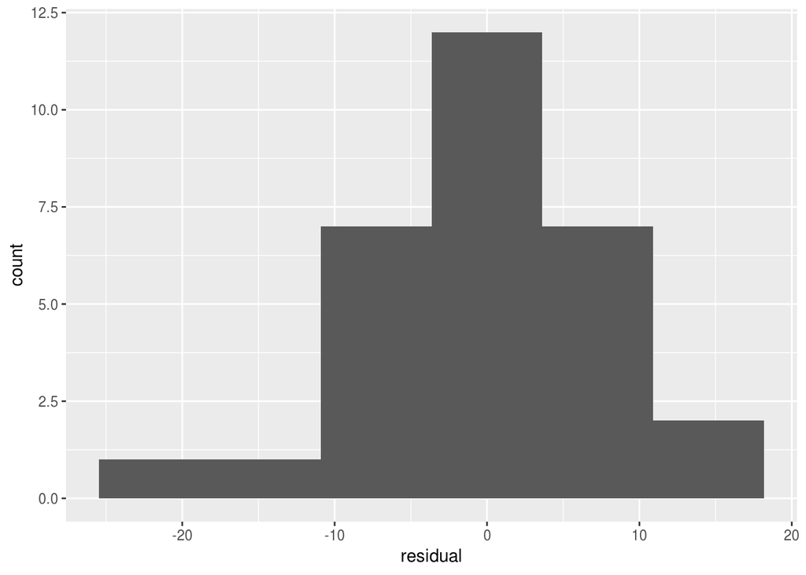

```r
wing_points <- get_regression_points(wing_model)

ggplot(wing_points, aes(x = residual)) +
  geom_histogram(bins = 6)
```

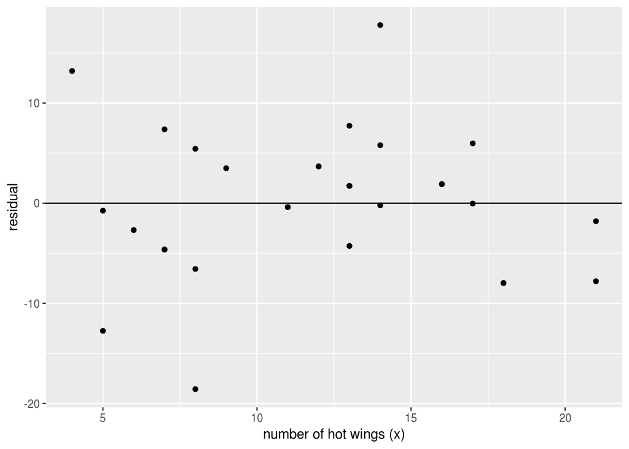

```r
ggplot(wing_points, aes(x = Hotwings, y = residual)) +
  geom_point() +
  geom_hline(yintercept = 0) +
  labs(x = "number of hot wings (x)")
```